# Google Cyclistic Capstone

2023-09-02

# 1. Problem statement

Cyclistic is a Chicago based bike-shar company who offers products to be inclusive to handicapped people. The future success of this company depends on maximazing the number of annual members and this analysis aims to find major difference between annual members and casual riders.

# 2. Data source

The data can be obtained here https://divvy-tripdata.s3.amazonaws.com/index.html. This dataset contains bike usage records from January to December in 2022. It documented the ride ID, membership status, bike type and other relavent information.

# 3. Data Processing

### **Investigate data integrity**

- Found NAs and 0s in end-latitude and end-longtitude

```r
## found NAs and 0s in end_lat and end_lng
summary(bike_2022$end_lat)
```

```
##    Min. 1st Qu.  Median    Mean 3rd Qu.    Max.    NA's
##    0.00   41.88   41.90   41.90   41.93   42.37    5858
```

```r
summary(bike_2022$end_lng)
```

```
##    Min. 1st Qu.  Median    Mean 3rd Qu.    Max.    NA's
##  -88.14  -87.66  -87.64  -87.65  -87.63    0.00    5858
```

- Found empty entries in column 5,6,7,8 (All station names and IDs)

```r
## column 5,6,7,8 have empty entry (all station number and id)
unique(which(bike_2022 == "", arr.ind=TRUE)[,2])
```

```
## [1] 5 6 7 8
```

- Found an outliers(i.e. ID 3327172413547F64) where the ride distance is unreasonable
- Decide use 10 miles as a filter based on histogram

```r
# Latitude and longitude conversion provided here: https://www.usgs.gov/faqs/how-much-distance-does-a-degree-minute-and-second-cover-your-maps

outlier_d <- bike_2022 %>%
  select(ride_id, end_lat, end_lng, start_lat, start_lng, member_casual)%>%
  filter(end_lat != 0,
         !is.na(end_lat),
         end_lng != 0,
         !is.na(end_lng))%>%
  mutate(distance = sqrt((end_lat*69-start_lat*69)^2+(end_lng*54.6-start_lng*54.6)^2)) %>%
  arrange(desc(distance))

head(outlier_d)
```

```
##            ride_id end_lat end_lng start_lat start_lng member_casual  distance
## 1 3327172413547F64 41.8646 -87.681  45.63503 -73.79648        casual 801.49309
## 2 353B37694B30396F 41.8700 -88.140  41.87881 -87.62958        member  27.87533
## 3 5CE2D7C544D25B78 42.3700 -87.830  42.05043 -87.67788        member  23.56285
## 4 D2A9A1120A165B1F 41.5500 -87.300  41.79432 -87.60140        member  23.55885
## 5 868D605CA8265D9C 41.5500 -87.300  41.79000 -87.60000        casual  23.29245
## 6 FCA626E6201EA16B 41.5500 -87.300  41.79000 -87.60000        member  23.29245
```

- Found reverted start and end time
- Found outlier in ride length(Possiblly explained by forgot to return)

```r
outlier_t <- bike_2022 %>%
  select(ride_id, started_at, ended_at)%>%
  mutate(ride_length = as.numeric(as.POSIXlt(ended_at)-as.POSIXlt(started_at)))%>%
  arrange(desc(ride_length))

test <- outlier_t %>%
  mutate(ride_length = abs(ride_length)/3600)

summary(test$ride_length)
```

```
##     Min.  1st Qu.   Median     Mean  3rd Qu.     Max.
##   0.0000   0.0969   0.1714   0.3241   0.3078 689.7875
```

### Filter outliers in ride distance

-Based on the histogram, the threshold for ride distance is set to 10 miles

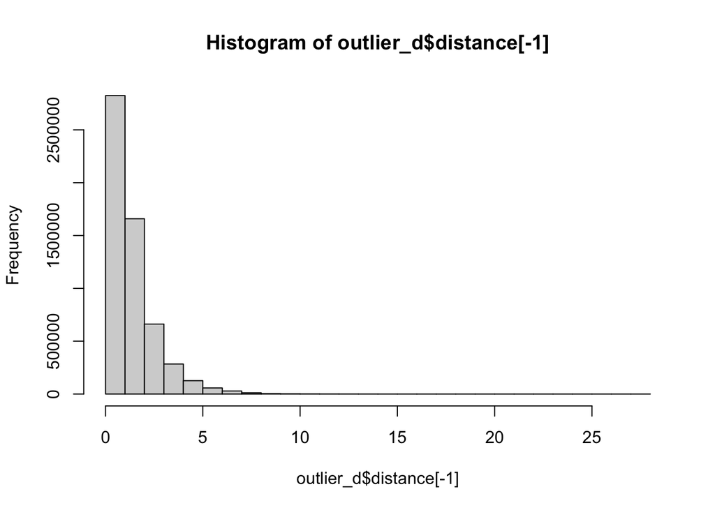

```r
# removed one extreme outlier(801 mile) for better observation
hist(outlier_d$distance[-1])
```

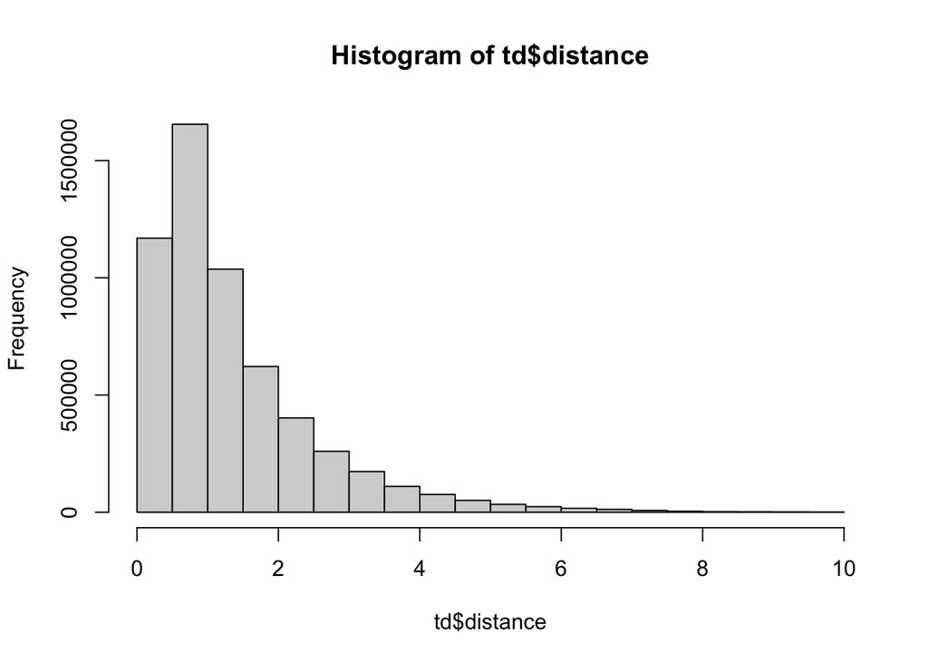

```r
td <- outlier_d %>%
  filter(distance < 10)
hist(td$distance)
```

### Filter outliers in ride time

- Based on histogram, the threshold for ride time is set to 2h

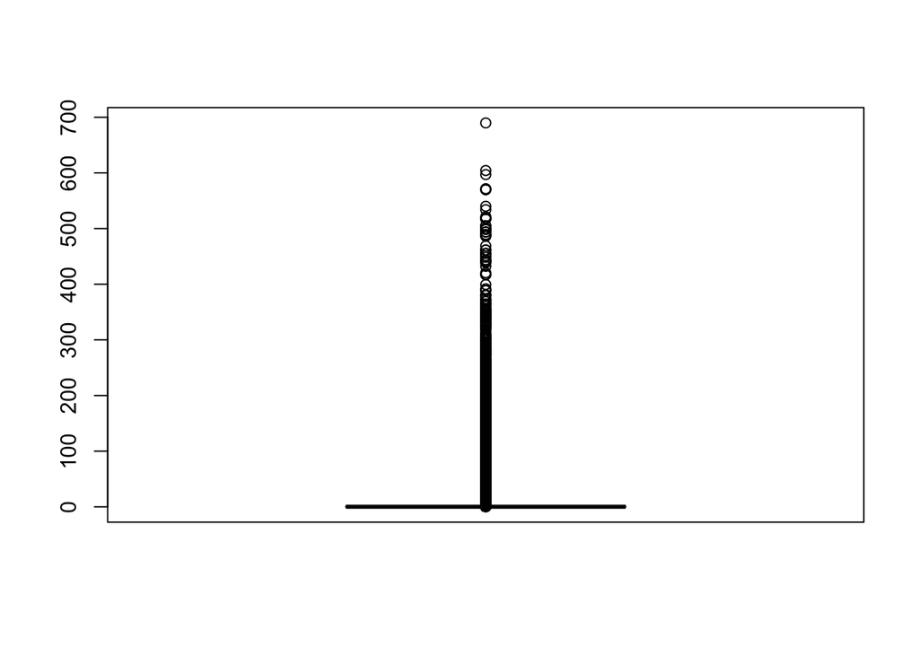

```r
boxplot(test$ride_length)
```

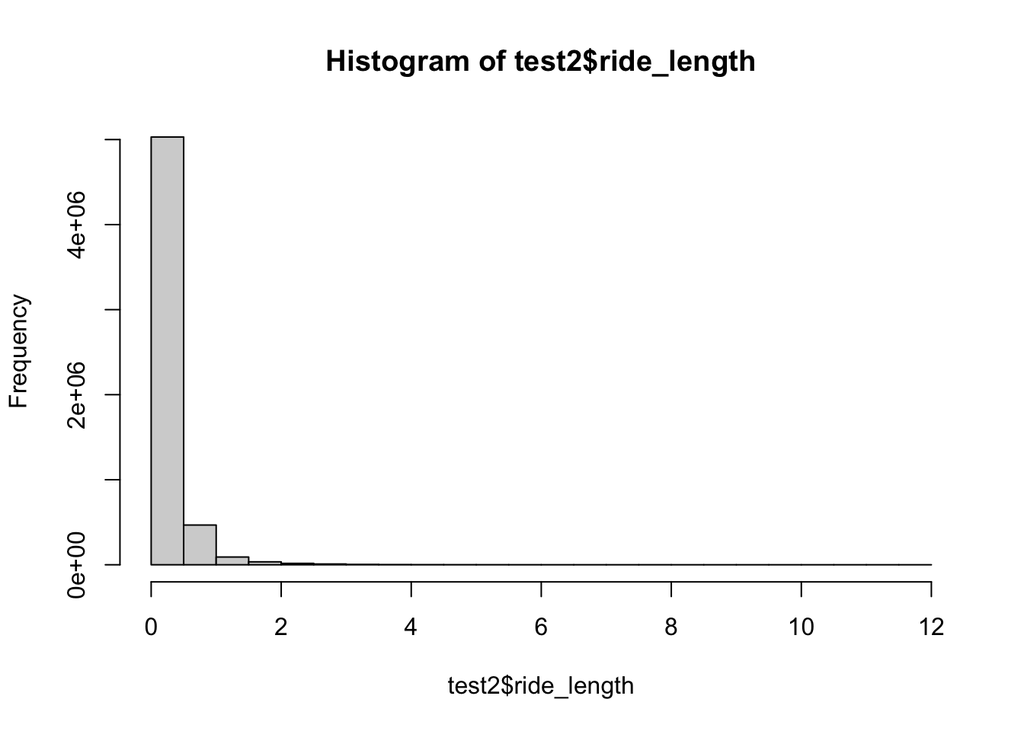

```r
# removed unreasonable time frame(>12h) for better observation
test2 <- test %>%
  filter(ride_length < 12 )
hist(test2$ride_length)
```

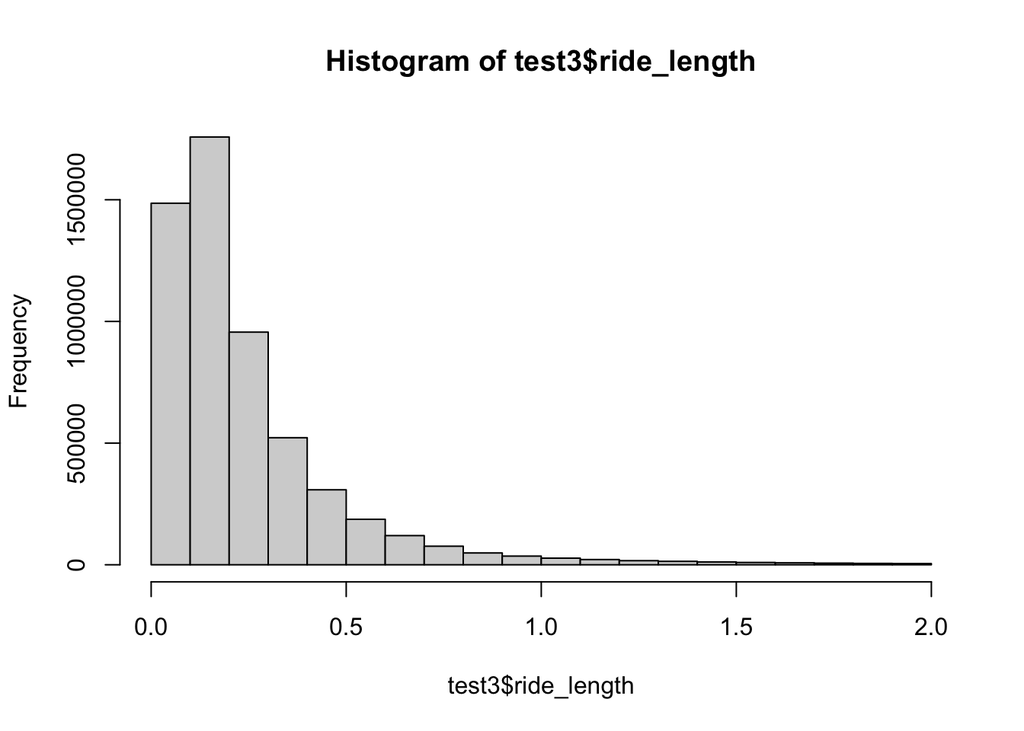

```r
test3 <- test2 %>%
  filter(ride_length < 2)
hist(test3$ride_length)
```

- Filter out problematic longitude and latitude data
- Apply filters on ride time and ride distance

```r
bike_final <- bike_2022 %>%
  # remove data with issues
  filter(end_lat != 0,
         !is.na(end_lat),
         end_lng != 0,
         !is.na(end_lng))%>%
  mutate(distance = sqrt((end_lat*69-start_lat*69)^2+(end_lng*54.6-start_lng*54.6)^2),
         weekday = weekdays(as.POSIXlt(started_at)),
         ride_length = abs(as.numeric(as.POSIXlt(ended_at)-as.POSIXlt(started_at)))/3600)%>%
  filter(ride_length < 2 & ride_length >0,
         distance < 10)

head(bike_final)
```

```
##            ride_id rideable_type          started_at            ended_at
## 1 C2F7DD78E82EC875 electric_bike 2022-01-13 11:59:47 2022-01-13 12:02:44
## 2 A6CF8980A652D272 electric_bike 2022-01-10 08:41:56 2022-01-10 08:46:17
## 3 BD0F91DFF741C66D  classic_bike 2022-01-25 04:53:40 2022-01-25 04:58:01
## 4 CBB80ED419105406  classic_bike 2022-01-04 00:18:04 2022-01-04 00:33:00
## 5 DDC963BFDDA51EEA  classic_bike 2022-01-20 01:31:10 2022-01-20 01:37:12
## 6 A39C6F6CC0586C0B  classic_bike 2022-01-11 18:48:09 2022-01-11 18:51:31
##              start_station_name start_station_id              end_station_name
## 1      Glenwood Ave & Touhy Ave              525          Clark St & Touhy Ave
## 2      Glenwood Ave & Touhy Ave              525          Clark St & Touhy Ave
## 3 Sheffield Ave & Fullerton Ave     TA1306000016 Greenview Ave & Fullerton Ave
## 4      Clark St & Bryn Mawr Ave     KA1504000151     Paulina St & Montrose Ave
## 5   Michigan Ave & Jackson Blvd     TA1309000002        State St & Randolph St
## 6         Wood St & Chicago Ave              637       Honore St & Division St
##   end_station_id start_lat start_lng  end_lat   end_lng member_casual month
## 1         RP-007  42.01280 -87.66591 42.01256 -87.67437        casual    01
## 2         RP-007  42.01276 -87.66597 42.01256 -87.67437        casual    01
## 3   TA1307000001  41.92560 -87.65371 41.92533 -87.66580        member    01
## 4   TA1309000021  41.98359 -87.66915 41.96151 -87.67139        casual    01
## 5   TA1305000029  41.87785 -87.62408 41.88462 -87.62783        member    01
## 6   TA1305000034  41.89563 -87.67207 41.90312 -87.67394        member    01
##    distance  weekday ride_length
## 1 0.4622746 Thursday  0.04916667
## 2 0.4588326   Monday  0.07250000
## 3 0.6604874  Tuesday  0.07250000
## 4 1.5288034  Tuesday  0.24888889
## 5 0.5101929 Thursday  0.10055556
## 6 0.5264184  Tuesday  0.05611111
```

```r
#bike_final <- readRDS("/Users/les928/Documents/Google_capstone/new_bike_final.rds")
```

# 4. Data Analyze

### **Plot1:Casual vs Member across month**

- Casual rider on average spend more time when riding a bike
- Casual rider tend to ride more during the weekend

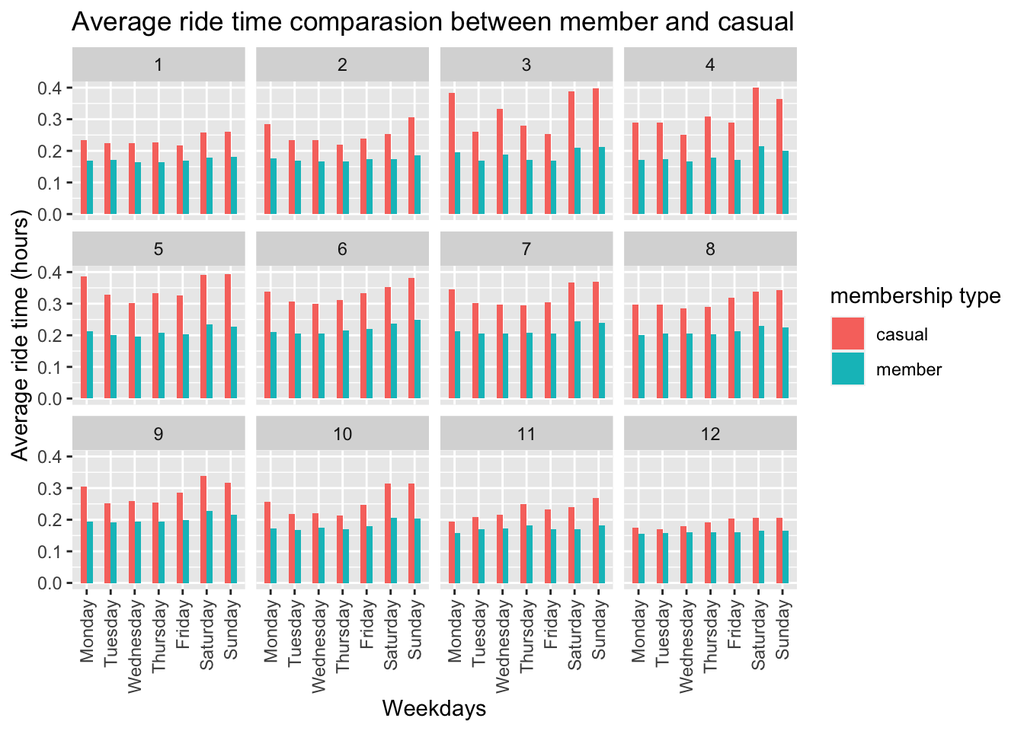

```r
## to provide correct order when plot weekdays
week_order <- c("Monday","Tuesday","Wednesday","Thursday","Friday","Saturday","Sunday")
plot1 <- bike_final %>%
  mutate(month = as.numeric(month))%>%
  group_by(member_casual, month, weekday)%>%
  summarise(ave_ride_len = mean(ride_length)) %>%
  ungroup()%>%
  ggplot(aes(x = factor(weekday, level = week_order), y = ave_ride_len))+
  geom_bar(aes(fill = member_casual), stat="identity", width=.5, position ="dodge")+
  facet_wrap(~ month)+
  theme(axis.text.x = element_text(angle = 90, vjust = 0.5, hjust=1))+
  xlab("Weekdays")+
  ylab("Average ride time (hours)")+
  labs(fill = "membership type")+
  ggtitle("Average ride time comparasion between member and casual")
print(plot1)
```

### **plot2: weekly usage summary**

- Seasonal impact on ride count (winter month less counts)
- Annual member rides more during weekdays
- Casual member rides more during weekends (less difference observed during weekdays)

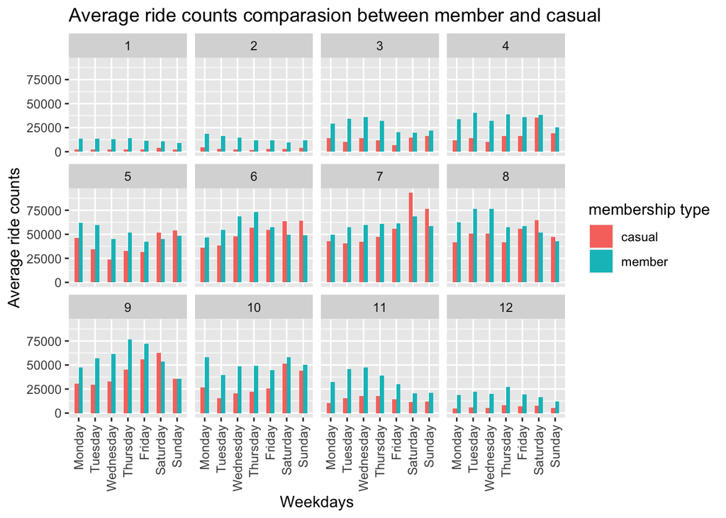

```r
plot2 <- bike_final %>%
  mutate(month = as.numeric(month))%>%
  group_by(month, member_casual, weekday) %>%
  summarise(count = n())%>%
  ungroup()%>%
  ggplot(aes(x = factor(weekday, level = week_order), y = count))+
  geom_bar(aes(fill = member_casual), stat="identity", width=.5, position ="dodge")+
  facet_wrap(~month)+
  theme(axis.text.x = element_text(angle = 90, vjust = 0.5, hjust=1))+
  xlab("Weekdays")+
  ylab("Average ride counts")+
  labs(fill = "membership type")+
  ggtitle("Average ride counts comparasion between member and casual")
print(plot2)
```

### **plot3: map distance between member and casual**

- Ride distance is very similar between member and casual
- Ride distance is less affected by seasonal factors and days within a week

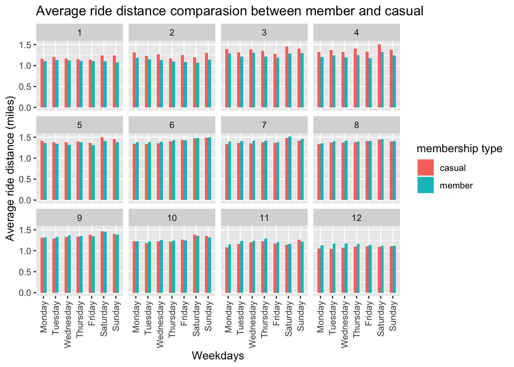

```r
plot3 <- bike_final %>%
  mutate(month = as.numeric(month))%>%
  group_by(month, member_casual, weekday) %>%
  summarise(ave_dist = mean(distance))%>%
  ungroup()%>%
  ggplot(aes(x = factor(weekday, level = week_order), y = ave_dist))+
  geom_bar(aes(fill = member_casual), stat="identity", width=.5, position ="dodge")+
  facet_wrap(~month)+
  theme(axis.text.x = element_text(angle = 90, vjust = 0.5, hjust=1))+
  xlab("Weekdays")+
  ylab("Average ride distance (miles)")+
  labs(fill = "membership type")+
  ggtitle("Average ride distance comparasion between member and casual")
print(plot3)
```

### **plot4: Ride time vs. ride count**

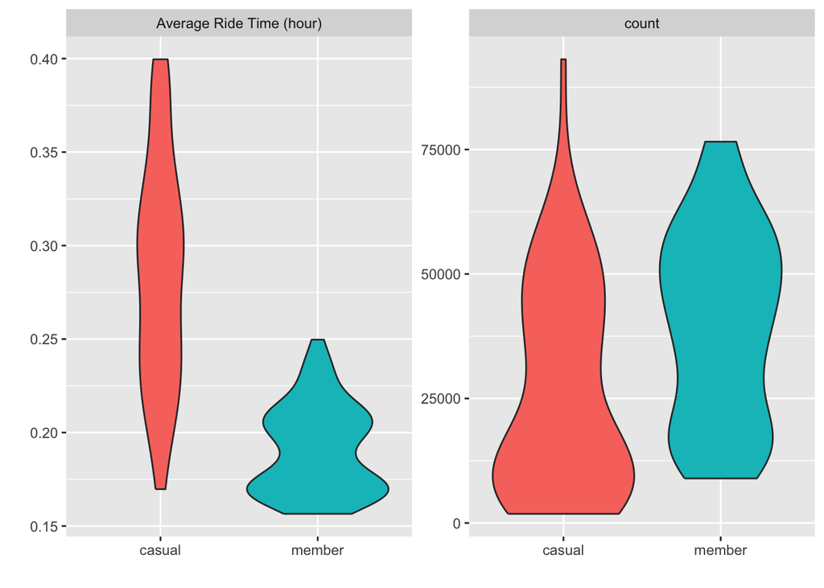

```r
plot4 <- bike_final %>%
  mutate(month = as.numeric(month))%>%
  group_by(member_casual, month, weekday)%>%
  summarise(`Average Ride Time (hour)` = mean(ride_length),
            count = n())%>%
  ungroup()%>%
  gather(key = xaxis, value = yaxis, 4:5)%>%
  ggplot(aes(x = member_casual, y = yaxis))+
  geom_violin(aes(fill = member_casual), show.legend = FALSE)+
  facet_wrap(~xaxis, scales = "free")+
  xlab("")+
  ylab("")
print(plot4)
```

### **plot5: ride count for bike type**

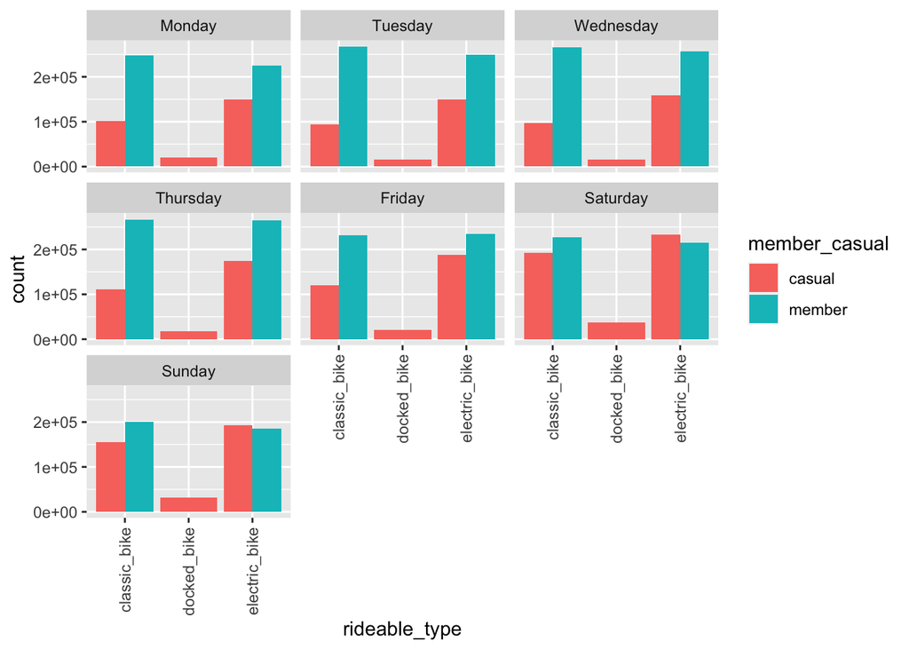

```r
bike_final$weekday <- factor(bike_final$weekday, levels = week_order)
plot5 <- bike_final %>%
  ggplot(aes(x = rideable_type, fill = member_casual))+
  geom_bar(stat = "count", position = "dodge") +
  facet_wrap(~weekday)+
  theme(axis.text.x = element_text(angle = 90, vjust = 0.5, hjust=1))

print(plot5)
```

## Discussion

In plot 1, members’ average ride-time is always shorter than the casual member. Considering the similar riding distance as shown in plot 3, members on average ride faster than the casual riders. This may infer that most members use Cyclyist for work commute and casual riders mainly use cyclist for leisure purpose. From plot 3, we see a very similar distribution of riding distance between casual rider and members, indicating the commute length is not a primary factor for annual subscription. There is also seasonal bias for average riding time. The average riding time for casual rider is longer when the weather is warmer which is between March and September. This evidence reinforce the fact that members and casual rider use cyclist for different purpose. In plot 2, we also see seasonal bias for both group, but this plot doesn’t refute the previous statement because significantly more members rides cyclist during winter. Another observation is that casual member tend to ride more cyclist during the weekend compared to members. These interpretation is not comprehensive due to the limited data and should only be used as a reference. In plot 5, we see a slight increase in electric bike usage compared to normal bike in casual users and no significantly difference between two type of bikes for annual members.

## Summary

- Casual riders tend to ride more during the weekend compared to weekdays.
- Annual members use cyclistic constantly during the week
- Casual riders ride time is longer than annual members
- Casual riders use it for leisure and casual use it for daily commute
- Annual members don’t seem to have a preference between electric and normal bikes, but casual riders ride more electric bikes

# Proposal

- Weekend points system: Casual member tend to ride more during the weekend, and members ride less during the weekend, having weekend benefit will encourage casual members to become members and annual members to ride more during the weekend
- Provide more bikes around the working and living area since most annual members use cyclistic for daily commute
- Collaborate with local franchise to allow member user to redeem their points for gift-cards or other rewards.